# Analysis of FitBit User Trends

Will Massey

8/18/2021

# Summary

We will be exploring a public dataset from Kaggle describing how users interact with their smart devices, in this case FitBit. We hope to gain valuable insights that can be applied to Bellabeat’s wearable technology to develop stronger marketing strategies for their wearable products. Bellabeat is a high-tech manufacturer of health-focused products for women who design wearable technology that track user’s activities and several health related metrics.

### Business questions at hand:

- What are some trends in smart device usage?
- How could these trends apply to Bellabeat customers?
- How could these trends help influence Bellabeat marketing strategy?

# Cleaning / Joining Datasets for Analysis

### Importing Packages and Datasets

```r
library(tidyverse)
library(lubridate)
library(tidyr)
library(dplyr)
library(ggplot2)
library(reshape2)
library(skimr)
library(ggpubr)

daily_activity = read.csv("bellabeat_data_raw/dailyActivity_merged.csv")
seconds_heartrate = read.csv("bellabeat_data_raw/heartrate_seconds_merged.csv")
daily_sleep = read.csv("bellabeat_data_raw/sleepDay_merged.csv")
```

### Formatting Dataframes

```r
## inspecting data and checking for NA
str(daily_activity)
writeLines('\nNumber of N/A per column:')
colSums(is.na(daily_activity))
## formatting date from type chr to date
daily_activity = daily_activity %>% mutate(Date = strptime(daily_activity$ActivityDate, "%m/%d/%Y"))
daily_activity$ActivityDate = NULL

## inspecting data and check for NA
str(seconds_heartrate)
writeLines('\nNumber of N/A per column:')
colSums(is.na(seconds_heartrate))
## formatting datetime from type chr to date
seconds_heartrate = seconds_heartrate %>% mutate(Date = strptime(seconds_heartrate$Time, "%m/%d/%Y"))
seconds_heartrate$Time = NULL

## getting daily average of heart rate by Id and Date
avg_heartrate = seconds_heartrate %>% group_by(Id, Date) %>% summarise_at(vars("Value"), mean) %>%
  rename(avg_heartrate = Value)
##joining average heart rate to main data by Id and Date
daily_activity = left_join(daily_activity, avg_heartrate, by = c("Id" = "Id", "Date" = "Date"))

## inspecting data and checking for NA
str(daily_sleep)
writeLines('\nNumber of N/A per column:')
colSums(is.na(daily_sleep))

daily_sleep = daily_sleep %>% mutate(Date = strptime(daily_sleep$SleepDay, "%m/%d/%Y"))
daily_sleep$SleepDay = NULL
##joining sleep data by Id and Date
daily_activity = left_join(daily_activity, daily_sleep, by = c("Id" = "Id", "Date" = "Date"))
```

```
## 'data.frame':  940 obs. of  15 variables:
##  $ Id                      : num  1.5e+09 1.5e+09 1.5e+09 1.5e+09 1.5e+09 ...
##  $ ActivityDate            : chr  "4/12/2016" "4/13/2016" "4/14/2016" "4/15/2016" ...
##  $ TotalSteps              : int  13162 10735 10460 9762 12669 9705 13019 15506 10544 9819 ...
##  $ TotalDistance           : num  8.5 6.97 6.74 6.28 8.16 ...
##  $ TrackerDistance         : num  8.5 6.97 6.74 6.28 8.16 ...
##  $ LoggedActivitiesDistance: num  0 0 0 0 0 0 0 0 0 0 ...
##  $ VeryActiveDistance      : num  1.88 1.57 2.44 2.14 2.71 ...
##  $ ModeratelyActiveDistance: num  0.55 0.69 0.4 1.26 0.41 ...
##  $ LightActiveDistance     : num  6.06 4.71 3.91 2.83 5.04 ...
##  $ SedentaryActiveDistance : num  0 0 0 0 0 0 0 0 0 0 ...
##  $ VeryActiveMinutes       : int  25 21 30 29 36 38 42 50 28 19 ...
##  $ FairlyActiveMinutes     : int  13 19 11 34 10 20 16 31 12 8 ...
##  $ LightlyActiveMinutes    : int  328 217 181 209 221 164 233 264 205 211 ...
##  $ SedentaryMinutes        : int  728 776 1218 726 773 539 1149 775 818 838 ...
##  $ Calories                : int  1985 1797 1776 1745 1863 1728 1921 2035 1786 1775 ...
##
## Number of N/A per column:
##                       Id             ActivityDate               TotalSteps
##                        0                        0                        0
##            TotalDistance          TrackerDistance LoggedActivitiesDistance
##                        0                        0                        0
##       VeryActiveDistance ModeratelyActiveDistance      LightActiveDistance
##                        0                        0                        0
##  SedentaryActiveDistance        VeryActiveMinutes      FairlyActiveMinutes
##                        0                        0                        0
##     LightlyActiveMinutes         SedentaryMinutes                 Calories
##                        0                        0                        0
## 'data.frame':    2483658 obs. of  3 variables:
##  $ Id   : num  2.02e+09 2.02e+09 2.02e+09 2.02e+09 2.02e+09 ...
##  $ Time : chr  "4/12/2016 7:21:00 AM" "4/12/2016 7:21:05 AM" "4/12/2016 7:21:10 AM" "4/12/2016 7:21:20 AM" ...
##  $ Value: int  97 102 105 103 101 95 91 93 94 93 ...
##
## Number of N/A per column:
##    Id  Time Value
##     0     0     0
## 'data.frame':    413 obs. of  5 variables:
##  $ Id                : num  1.5e+09 1.5e+09 1.5e+09 1.5e+09 1.5e+09 ...
##  $ SleepDay          : chr  "4/12/2016 12:00:00 AM" "4/13/2016 12:00:00 AM" "4/15/2016 12:00:00 AM" "4/16/2016 12:00:00 AM" ...
##  $ TotalSleepRecords : int  1 2 1 2 1 1 1 1 1 1 ...
##  $ TotalMinutesAsleep: int  327 384 412 340 700 304 360 325 361 430 ...
##  $ TotalTimeInBed    : int  346 407 442 367 712 320 377 364 384 449 ...
##
## Number of N/A per column:
##                 Id           SleepDay  TotalSleepRecords TotalMinutesAsleep
##                  0                  0                  0                  0
##     TotalTimeInBed
##                  0
```

Our joined dataframe for analysis:

```r
skim(daily_activity)
```

Data summary

| Name | daily_activity |
| --- | --- |
| Number of rows | 943 |
| Number of columns | 19 |
| _______________________ |  |
| Column type frequency: |  |
| numeric | 18 |
| POSIXct | 1 |
| ________________________ |  |
| Group variables | None |

**Variable type: numeric**

| skim_variable | n_missing | complete_rate | mean | sd | p0 | p25 | p50 | p75 | p100 | hist |
| --- | --- | --- | --- | --- | --- | --- | --- | --- | --- | --- |
| Id | 0 | 1.00 | 4.858486e+09 | 2.423712e+09 | 1.50396e+09 | 2.320127e+09 | 4.445115e+09 | 6.962181e+09 | 8.877689e+09 | ▇▅▃▅▅ |
| TotalSteps | 0 | 1.00 | 7.652190e+03 | 5.086530e+03 | 0.00000e+00 | 3.795000e+03 | 7.439000e+03 | 1.073400e+04 | 3.601900e+04 | ▇▇▁▁▁ |
| TotalDistance | 0 | 1.00 | 5.500000e+00 | 3.930000e+00 | 0.00000e+00 | 2.620000e+00 | 5.260000e+00 | 7.720000e+00 | 2.803000e+01 | ▇▆▁▁▁ |
| TrackerDistance | 0 | 1.00 | 5.490000e+00 | 3.910000e+00 | 0.00000e+00 | 2.620000e+00 | 5.260000e+00 | 7.710000e+00 | 2.803000e+01 | ▇▆▁▁▁ |
| LoggedActivitiesDistance | 0 | 1.00 | 1.100000e-01 | 6.200000e-01 | 0.00000e+00 | 0.000000e+00 | 0.000000e+00 | 0.000000e+00 | 4.940000e+00 | ▇▁▁▁▁ |
| VeryActiveDistance | 0 | 1.00 | 1.500000e+00 | 2.660000e+00 | 0.00000e+00 | 0.000000e+00 | 2.200000e-01 | 2.060000e+00 | 2.192000e+01 | ▇▁▁▁▁ |
| ModeratelyActiveDistance | 0 | 1.00 | 5.700000e-01 | 8.800000e-01 | 0.00000e+00 | 0.000000e+00 | 2.400000e-01 | 8.100000e-01 | 6.480000e+00 | ▇▁▁▁▁ |
| LightActiveDistance | 0 | 1.00 | 3.350000e+00 | 2.050000e+00 | 0.00000e+00 | 1.950000e+00 | 3.380000e+00 | 4.790000e+00 | 1.071000e+01 | ▆▇▆▁▁ |
| SedentaryActiveDistance | 0 | 1.00 | 0.000000e+00 | 1.000000e-02 | 0.00000e+00 | 0.000000e+00 | 0.000000e+00 | 0.000000e+00 | 1.100000e-01 | ▇▁▁▁▁ |
| VeryActiveMinutes | 0 | 1.00 | 2.124000e+01 | 3.295000e+01 | 0.00000e+00 | 0.000000e+00 | 4.000000e+00 | 3.200000e+01 | 2.100000e+02 | ▇▁▁▁▁ |
| FairlyActiveMinutes | 0 | 1.00 | 1.363000e+01 | 2.000000e+01 | 0.00000e+00 | 0.000000e+00 | 7.000000e+00 | 1.900000e+01 | 1.430000e+02 | ▇▁▁▁▁ |
| LightlyActiveMinutes | 0 | 1.00 | 1.930300e+02 | 1.093100e+02 | 0.00000e+00 | 1.270000e+02 | 1.990000e+02 | 2.640000e+02 | 5.180000e+02 | ▅▇▇▃▁ |
| SedentaryMinutes | 0 | 1.00 | 9.903500e+02 | 3.012600e+02 | 0.00000e+00 | 7.290000e+02 | 1.057000e+03 | 1.229000e+03 | 1.440000e+03 | ▁▁▇▅▇ |
| Calories | 0 | 1.00 | 2.307510e+03 | 7.208200e+02 | 0.00000e+00 | 1.829500e+03 | 2.140000e+03 | 2.796500e+03 | 4.900000e+03 | ▁▆▇▃▁ |
| avg_heartrate | 608 | 0.36 | 7.856000e+01 | 1.064000e+01 | 5.93800e+01 | 7.044000e+01 | 7.744000e+01 | 8.490000e+01 | 1.097900e+02 | ▆▇▇▃▁ |
| TotalSleepRecords | 530 | 0.44 | 1.120000e+00 | 3.500000e-01 | 1.00000e+00 | 1.000000e+00 | 1.000000e+00 | 1.000000e+00 | 3.000000e+00 | ▇▁▁▁▁ |
| TotalMinutesAsleep | 530 | 0.44 | 4.194700e+02 | 1.183400e+02 | 5.80000e+01 | 3.610000e+02 | 4.330000e+02 | 4.900000e+02 | 7.960000e+02 | ▁▂▇▃▁ |
| TotalTimeInBed | 530 | 0.44 | 4.586400e+02 | 1.271000e+02 | 6.10000e+01 | 4.030000e+02 | 4.630000e+02 | 5.260000e+02 | 9.610000e+02 | ▁▃▇▁▁ |

**Variable type: POSIXct**

| skim_variable | n_missing | complete_rate | min | max | median | n_unique |
| --- | --- | --- | --- | --- | --- | --- |
| Date | 0 | 1 | 2016-04-12 | 2016-05-12 | 2016-04-26 | 31 |

It appears over half of our subjects’ daily sleep and heart rate data are unavailable. By having incomplete data, we lose some ability to give an accurate analysis. Also per the datasets description, users wore different devices and / or had different personal tracking preferences. In order to get an accurate analysis, we will be plotting each user on their own charts. Their ID will be displayed at the top of each chart.

# Discovering Trends in the Data

We will begin by plotting how many calories each user burns by how many steps they take in a given day.

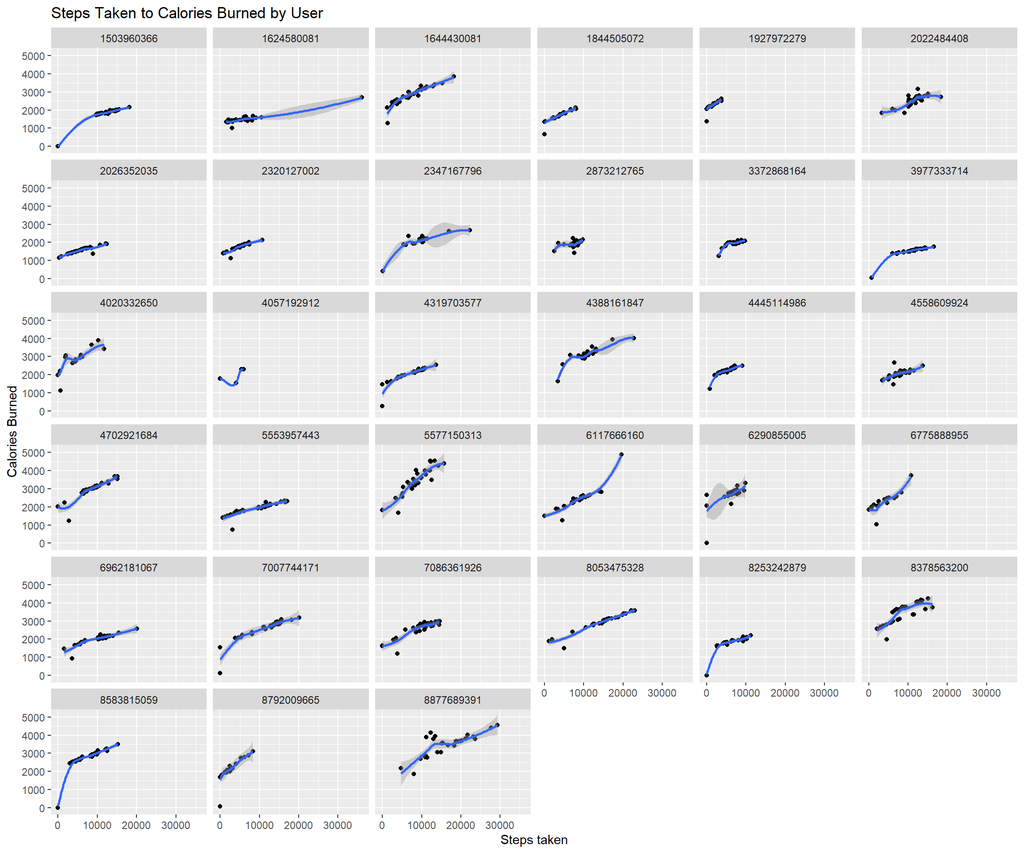

```r
## plot relationship of steps walked and calories burned per user
ggplot(data = daily_activity) + geom_point(mapping = aes(x = TotalSteps, y = Calories)) +
  geom_smooth(mapping = aes(x = TotalSteps, y = Calories)) +
  facet_wrap(~Id) +
  labs(title = "Steps Taken to Calories Burned by User", x = "Steps taken", y = "Calories Burned")
```

As expected, users who take more steps tend to burn more calories. Bellabeat marketing and design could incorporate reminders and incentives through their mobile apps to encourage more steps being taken throughout the day to help burn more calories.

Next we plot the relationship between steps taken each day over a small period of time to gain insights on each user’s activity.

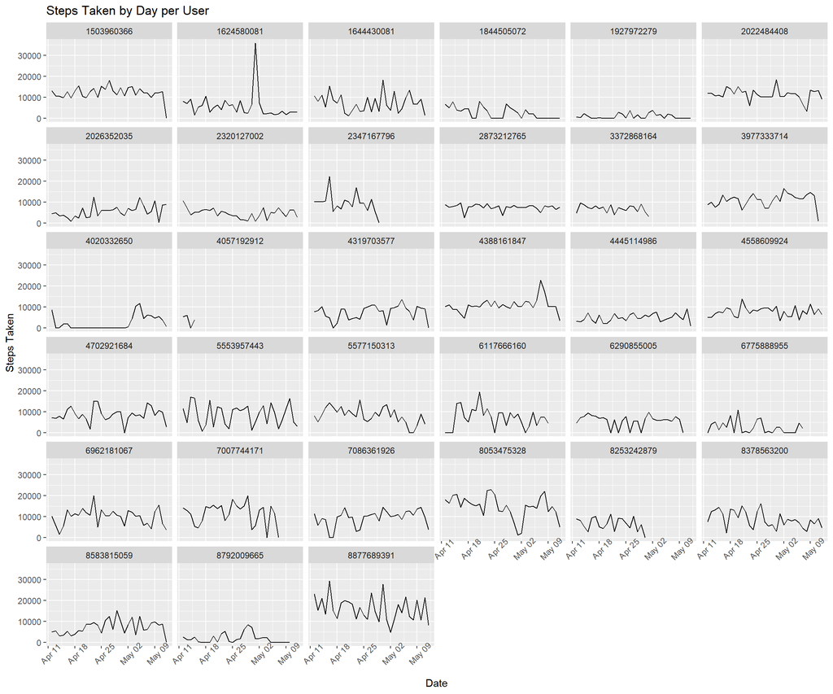

```r
ggplot(data = daily_activity) + geom_line(mapping = aes(x = Date, y = TotalSteps)) +
  facet_wrap(~Id) +
  labs(title = "Steps Taken by Day per User", x = "Date", y = "Steps Taken") +
  theme(axis.text.x = element_text(angle = 45))
```

It appears most users go from higher steps per day to lower steps per day, in a cycle. If the same user trends exists for Bellabeat smart device users, then one way to improve company growth is to somehow break that cycle. This would lead to more steps being taken on a weekly basis and more calories being burned, increasing overall user satisfaction and more products being used.

Next we will gain insights from the average intensity of each user’s activities throughout the day. Activities are rated from very active to inactive.

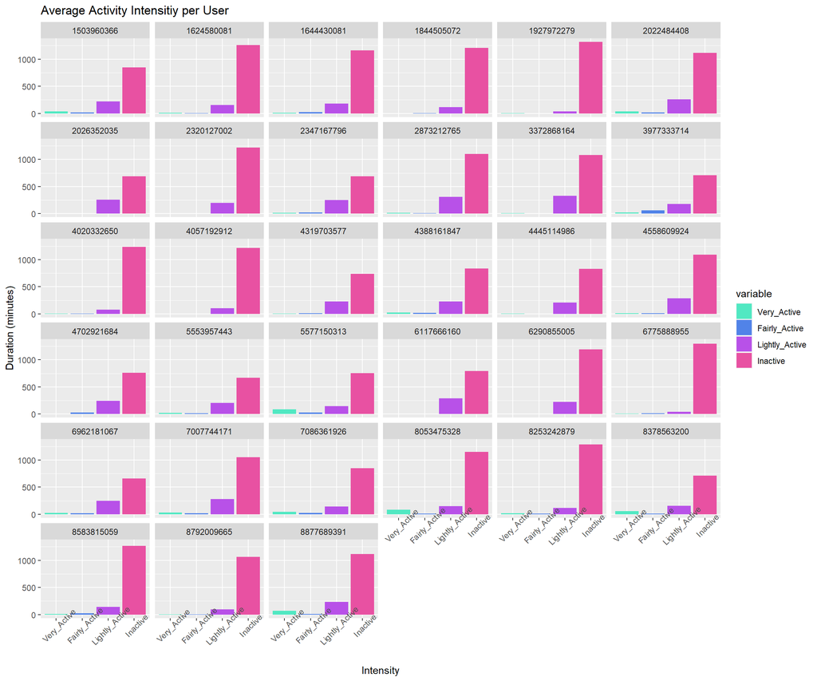

```r
avg_intensity = daily_activity %>% group_by(Id) %>%
  summarise_at(vars("VeryActiveMinutes", "FairlyActiveMinutes", "LightlyActiveMinutes", "SedentaryMinutes"), mean)
names(avg_intensity) = c("Id", "Very_Active", "Fairly_Active", "Lightly_Active", "Inactive")

## melting data to visualize
avg_intensity_long = melt(avg_intensity, id.vars=c("Id"))
ggplot(data = avg_intensity_long, aes(x=variable, y=value, fill=variable)) +
  geom_bar(stat="identity") + facet_wrap(~Id) +
  labs(title = "Average Activity Intensitiy per User", x = "Intensity", y = "Duration (minutes)") +
  theme(axis.text.x = element_text(angle = 45)) +
  scale_fill_manual(values = color_pallet)
```

It appears that each user has high rates of inactive activity, however we must remember that users are inactive while they are sleeping. We will replot our data without the inactive column to get a closer look at each user’s average activity intensity.

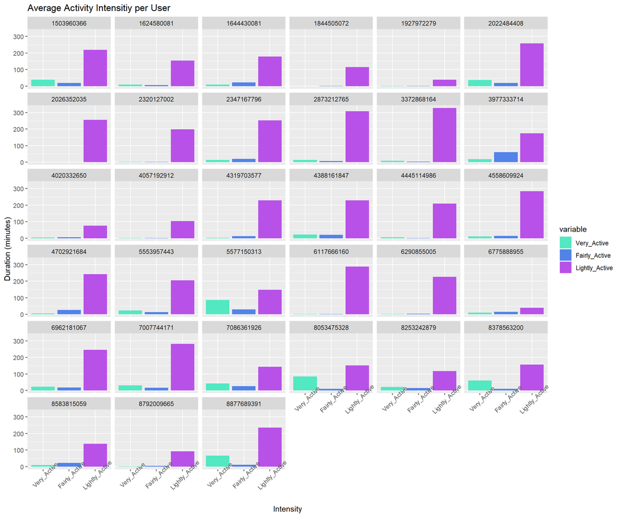

When users are being active, they tend to stay in the “lightly active” category. It also appears that most users spend more time in the “very active” category versus the “fairly active” category. We can now plot the relationship between activity intensity and calories burned.

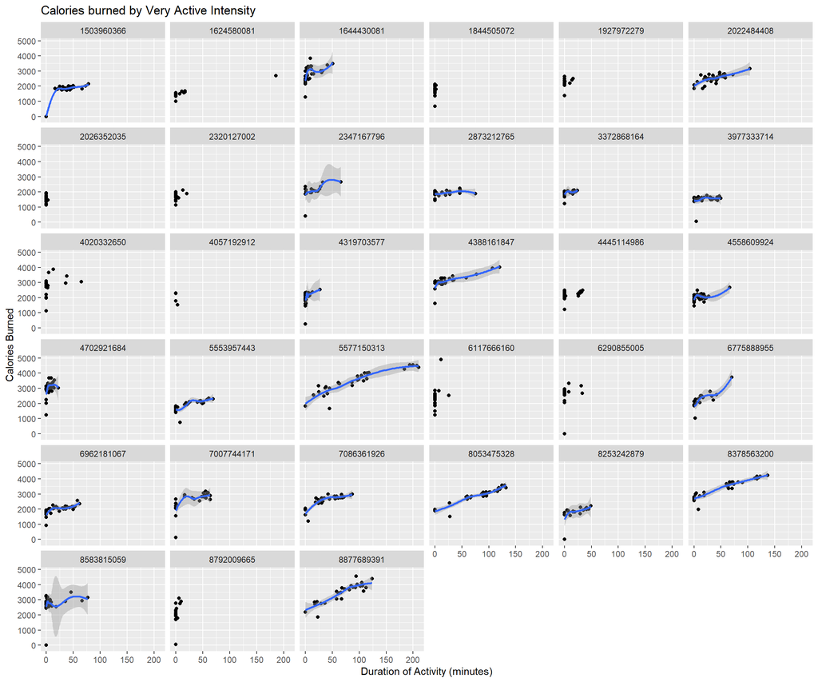

```r
## Very Active Intensity
ggplot(data = daily_activity) + geom_point(mapping = aes(x = VeryActiveMinutes, y = Calories)) +
  geom_smooth(mapping = aes(x = VeryActiveMinutes, y = Calories)) +
  facet_wrap(~Id) +
  labs(title = "Calories burned by Very Active Intensity", x = "Duration of Activity (minutes)", y = "Calories Burned")
```

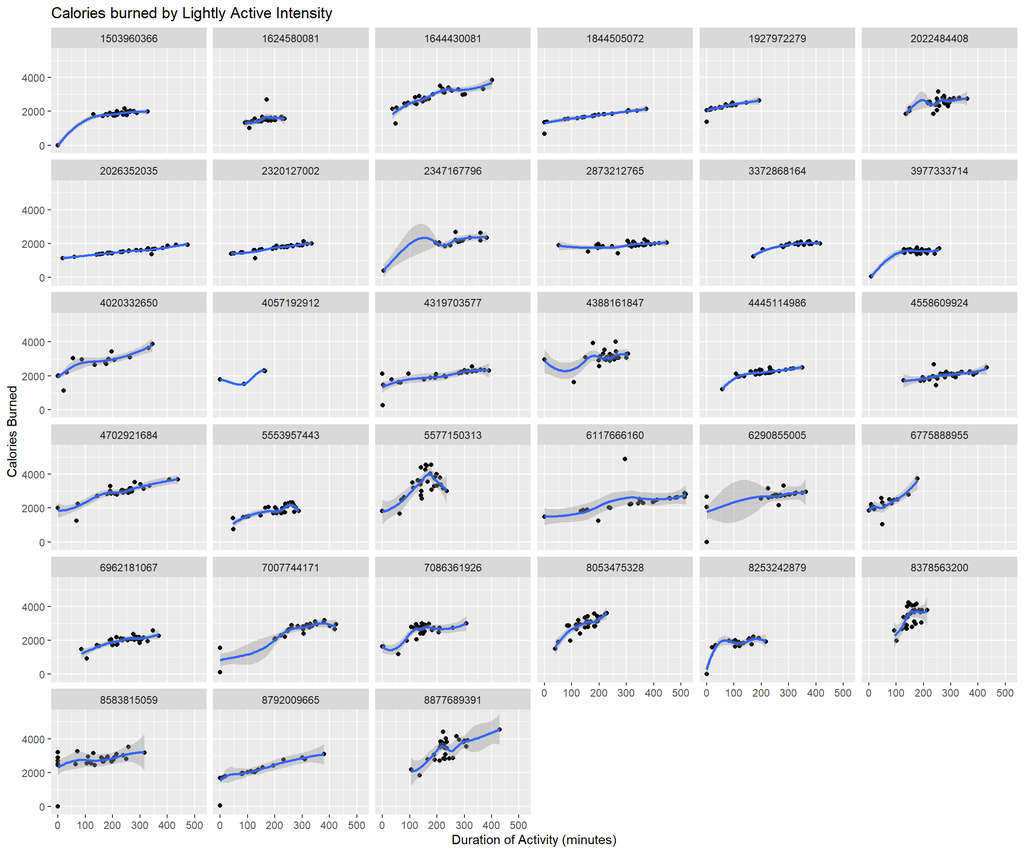

```r
## Lightly Active Intensity
ggplot(data = daily_activity) + geom_point(mapping = aes(x = LightlyActiveMinutes, y = Calories)) +
  geom_smooth(mapping = aes(x = LightlyActiveMinutes, y = Calories)) +
  facet_wrap(~Id) +
  labs(title = "Calories burned by Lightly Active Intensity", x = "Duration of Activity (minutes)", y = "Calories Burned")
```

As expected, typically the longer you stay active the more calories you burn. It appears to take considerably less time to burn more calories when being very active compared to being just lightly active. Knowing that users tend to stay more in the lightly active / inactive categories, Bellabeat’s technology could motivate users to complete their calorie goal for the day quicker by promoting a quick exercise, increasing usage of several Bellabeat products.

Next we will explore the relationship between total time in bed and calories burned for the day. Please note that half our users’ sleep data was unavailable, so analysis may not be as accurate as the above analyses.

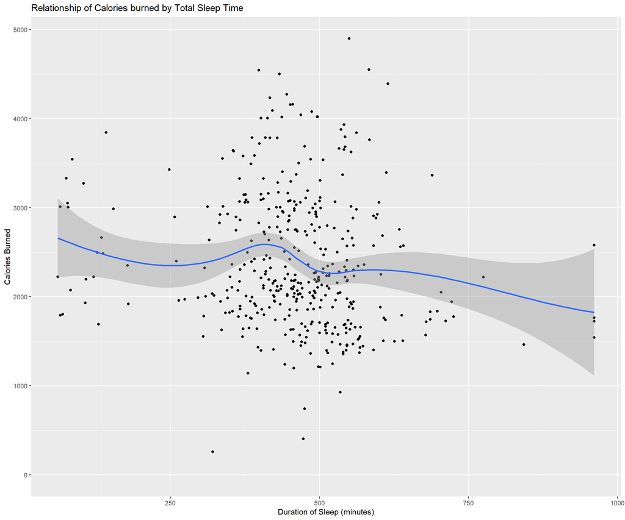

```r
ggplot(data = daily_activity) + geom_point(mapping = aes(x = TotalTimeInBed, y = Calories)) +
  geom_smooth(mapping = aes(x = TotalTimeInBed, y = Calories)) +
  labs(title = "Relationship of Calories burned by Total Sleep Time", x = "Duration of Sleep (minutes)", y = "Calories Burned")
```

There appears to be no relationship between sleep and calories burned throughout the day. We will now explore the correlation between average heart rate and calories burned for the day. Note that our available heart rate data is limited, so analysis may not be as accurate as above analyses.

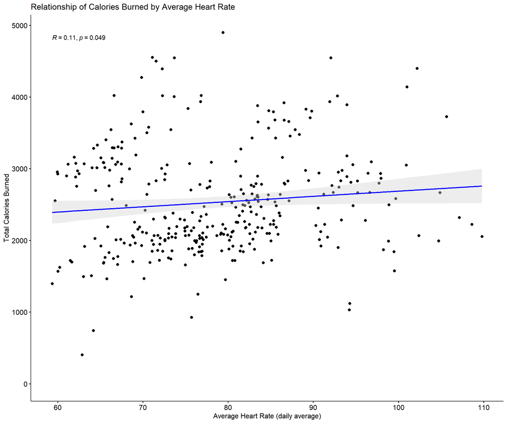

```r
ggscatter(daily_activity, x = "avg_heartrate", y = "Calories",
          add = "reg.line", conf.int = TRUE,
          add.params = list(color="blue", fill="lightgray"),
          cor.coef = TRUE, cor.method = "pearson",
          title = "Relationship of Calories Burned by Average Heart Rate",
          xlab = "Average Heart Rate (daily average)",
          ylab = "Total Calories Burned")
```

# Conclusion

- Users tend to burn more calories the more steps they take. Bellabeat products, like the Leaf or Time, could excel in this area by connecting to the Bellabeat app and keep track of several metrics to showcase progress.
- Smart device users tend to go from periods of lower activity to periods of higher activity, in a cycle. If the same trend exists for Bellabeat users, then breaking that cycle could potentially lead to more sales by achieving results quicker. By having the app downloaded, users could be reminded periodically about their progress and how they compared to the previous days.
- Most users spend most of their time being inactive or only lightly active, and not much time being very active in comparison. Also, it takes much less time per day to burn more calories by being highly active versus being lightly active. By reminding users of their activity rate, it could motivate them to become more active, using Bellabeat devices more often. By being more active, you will also need to stay hydrated and keep up with the amount of water you intake. This could also lead to more sales for Bellabeat’s Spring product. Also, this leads for opportunity for the Bellabeat membership program to step up and create a personalized routine for their users.
- Better recording of data such as: sleep, weight, and heart rate, could lead to better insights in the future.